# Data _ Analysis final

#### 24/04/2026 (day5)

```python
import pandas as pd
```

```python
df=pd.read_csv("Cleaned_GlobalWeatherRepository.csv")
```

```python
df
```

|  | country | location_name | latitude | longitude | timezone | last_updated | temperature_celsius | condition_text | wind_kph | wind_degree | ... | moonset | moon_phase | moon_illumination | date | time | continent | city | year | month | hour |
| --- | --- | --- | --- | --- | --- | --- | --- | --- | --- | --- | --- | --- | --- | --- | --- | --- | --- | --- | --- | --- | --- |
| 0 | Afghanistan | Kabul | 34.5200 | 69.1800 | Asia/Kabul | 2024-05-16 13:15:00 | 26.6 | Partly Cloudy | 13.3 | 338 | ... | 01:11 | Waxing Gibbous | 55 | 2024-05-16 | 13:15:00 | Asia | Kabul | 2024 | 5 | 13 |
| 1 | Albania | Tirana | 41.3300 | 19.8200 | Europe/Tirane | 2024-05-16 10:45:00 | 19.0 | Partly Cloudy | 11.2 | 320 | ... | 02:14 | Waxing Gibbous | 55 | 2024-05-16 | 10:45:00 | Europe | Tirane | 2024 | 5 | 10 |
| 2 | Algeria | Algiers | 36.7600 | 3.0500 | Africa/Algiers | 2024-05-16 09:45:00 | 23.0 | Sunny | 15.1 | 280 | ... | 02:14 | Waxing Gibbous | 55 | 2024-05-16 | 09:45:00 | Africa | Algiers | 2024 | 5 | 9 |
| 3 | Andorra | Andorra La Vella | 42.5000 | 1.5200 | Europe/Andorra | 2024-05-16 10:45:00 | 6.3 | Light Drizzle | 11.9 | 215 | ... | 03:31 | Waxing Gibbous | 55 | 2024-05-16 | 10:45:00 | Europe | Andorra | 2024 | 5 | 10 |
| 4 | Angola | Luanda | -8.8400 | 13.2300 | Africa/Luanda | 2024-05-16 09:45:00 | 26.0 | Partly Cloudy | 13.0 | 150 | ... | 00:38 | Waxing Gibbous | 55 | 2024-05-16 | 09:45:00 | Africa | Luanda | 2024 | 5 | 9 |
| ... | ... | ... | ... | ... | ... | ... | ... | ... | ... | ... | ... | ... | ... | ... | ... | ... | ... | ... | ... | ... | ... |
| 135068 | Venezuela | Caracas | 10.5000 | -66.9167 | America/Caracas | 2026-04-12 02:30:00 | 19.1 | Partly Cloudy | 3.6 | 178 | ... | 14:31 | Waning Crescent | 31 | 2026-04-12 | 02:30:00 | America | Caracas | 2026 | 4 | 2 |
| 135069 | Vietnam | Hanoi | 21.0333 | 105.8500 | Asia/Bangkok | 2026-04-12 13:30:00 | 34.2 | Sunny | 11.2 | 245 | ... | 13:21 | Waning Crescent | 35 | 2026-04-12 | 13:30:00 | Asia | Bangkok | 2026 | 4 | 13 |
| 135070 | Yemen | Sanaa | 15.3547 | 44.2067 | Asia/Aden | 2026-04-12 09:30:00 | 19.3 | Sunny | 6.5 | 217 | ... | 13:45 | Waning Crescent | 34 | 2026-04-12 | 09:30:00 | Asia | Aden | 2026 | 4 | 9 |
| 135071 | Zambia | Lusaka | -15.4167 | 28.2833 | Africa/Lusaka | 2026-04-12 08:30:00 | 18.5 | Sunny | 13.7 | 90 | ... | 14:30 | Waning Crescent | 33 | 2026-04-12 | 08:30:00 | Africa | Lusaka | 2026 | 4 | 8 |
| 135072 | Zimbabwe | Harare | -17.8178 | 31.0447 | Africa/Harare | 2026-04-12 08:30:00 | 17.4 | Sunny | 7.9 | 43 | ... | 14:22 | Waning Crescent | 33 | 2026-04-12 | 08:30:00 | Africa | Harare | 2026 | 4 | 8 |

135073 rows × 40 columns

```python
df.columns
```

```
Index(['country', 'location_name', 'latitude', 'longitude', 'timezone',
       'last_updated', 'temperature_celsius', 'condition_text', 'wind_kph',
       'wind_degree', 'wind_direction', 'pressure_mb', 'precip_mm', 'humidity',
       'cloud', 'feels_like_celsius', 'visibility_km', 'uv_index', 'gust_kph',
       'air_quality_Carbon_Monoxide', 'air_quality_Ozone',
       'air_quality_Nitrogen_dioxide', 'air_quality_Sulphur_dioxide',
       'air_quality_PM2.5', 'air_quality_PM10', 'air_quality_us-epa-index',
       'air_quality_gb-defra-index', 'sunrise', 'sunset', 'moonrise',
       'moonset', 'moon_phase', 'moon_illumination', 'date', 'time',
       'continent', 'city', 'year', 'month', 'hour'],
      dtype='object')
```

```python
df["latitude"].mean()
```

```
np.float64(19.208948125087915)
```

```python
df["latitude"].median()
```

```
17.25
```

```python
df["latitude"].mode()
```

```
0    41.9
Name: latitude, dtype: float64
```

```python
df.std(numeric_only=True)
```

```
latitude                         24.416748
longitude                        65.787645
temperature_celsius               9.699084
wind_kph                         11.624983
wind_degree                     103.706143
pressure_mb                      10.369057
precip_mm                         0.564297
humidity                         23.888068
cloud                            34.105307
feels_like_celsius               11.603120
visibility_km                     2.692115
uv_index                          3.550620
gust_kph                         13.829708
air_quality_Carbon_Monoxide     758.835655
air_quality_Ozone                30.777578
air_quality_Nitrogen_dioxide     23.723174
air_quality_Sulphur_dioxide      35.691840
air_quality_PM2.5                36.911798
air_quality_PM10                149.473695
air_quality_us-epa-index          0.941003
air_quality_gb-defra-index        2.445307
moon_illumination                35.022525
year                              0.662918
month                             3.496042
hour                              4.733891
dtype: float64
```

```python
df.describe()
```

|  | latitude | longitude | temperature_celsius | wind_kph | wind_degree | pressure_mb | precip_mm | humidity | cloud | feels_like_celsius | ... | air_quality_Nitrogen_dioxide | air_quality_Sulphur_dioxide | air_quality_PM2.5 | air_quality_PM10 | air_quality_us-epa-index | air_quality_gb-defra-index | moon_illumination | year | month | hour |
| --- | --- | --- | --- | --- | --- | --- | --- | --- | --- | --- | --- | --- | --- | --- | --- | --- | --- | --- | --- | --- | --- |
| count | 135073.000000 | 135073.000000 | 135073.000000 | 135073.000000 | 135073.000000 | 135073.000000 | 135073.000000 | 135073.000000 | 135073.000000 | 135073.000000 | ... | 135073.000000 | 135073.000000 | 135073.000000 | 135073.000000 | 135073.000000 | 135073.000000 | 135073.000000 | 135073.000000 | 135073.000000 | 135073.000000 |
| mean | 19.208948 | 21.961711 | 21.283607 | 12.913410 | 168.894909 | 1014.069244 | 0.134728 | 66.626135 | 40.022114 | 22.136784 | ... | 15.007413 | 10.365922 | 24.211112 | 48.433111 | 1.699200 | 2.605791 | 49.986444 | 2024.815174 | 6.634694 | 10.977131 |
| std | 24.416748 | 65.787645 | 9.699084 | 11.624983 | 103.706143 | 10.369057 | 0.564297 | 23.888068 | 34.105307 | 11.603120 | ... | 23.723174 | 35.691840 | 36.911798 | 149.473695 | 0.941003 | 2.445307 | 35.022525 | 0.662918 | 3.496042 | 4.733891 |
| min | -41.300000 | -175.200000 | -29.800000 | 3.600000 | 1.000000 | 947.000000 | 0.000000 | 2.000000 | 0.000000 | -36.700000 | ... | 0.000000 | -9999.000000 | 0.168000 | -1848.150000 | 1.000000 | 1.000000 | 0.000000 | 2024.000000 | 1.000000 | 0.000000 |
| 25% | 4.050300 | -6.836100 | 16.000000 | 6.100000 | 80.000000 | 1010.000000 | 0.000000 | 51.000000 | 0.000000 | 16.000000 | ... | 1.665000 | 1.110000 | 7.050000 | 9.990000 | 1.000000 | 1.000000 | 15.000000 | 2024.000000 | 3.000000 | 8.000000 |
| 50% | 17.250000 | 23.236100 | 24.000000 | 10.800000 | 161.000000 | 1014.000000 | 0.000000 | 72.000000 | 31.000000 | 25.100000 | ... | 5.550000 | 2.405000 | 14.200000 | 19.980000 | 1.000000 | 2.000000 | 50.000000 | 2025.000000 | 7.000000 | 11.000000 |
| 75% | 40.400000 | 49.882200 | 28.000000 | 17.600000 | 256.000000 | 1018.000000 | 0.030000 | 86.000000 | 75.000000 | 29.900000 | ... | 17.390000 | 8.325000 | 27.750000 | 41.450000 | 2.000000 | 3.000000 | 85.000000 | 2025.000000 | 10.000000 | 14.000000 |
| max | 64.150000 | 179.220000 | 49.200000 | 2963.200000 | 360.000000 | 3006.000000 | 42.240000 | 100.000000 | 100.000000 | 51.200000 | ... | 427.700000 | 521.330000 | 1614.100000 | 6037.290000 | 6.000000 | 10.000000 | 100.000000 | 2026.000000 | 12.000000 | 23.000000 |

8 rows × 25 columns

# BAR CHART

### Country

```python
import matplotlib.pyplot as plt
import seaborn as sns
```

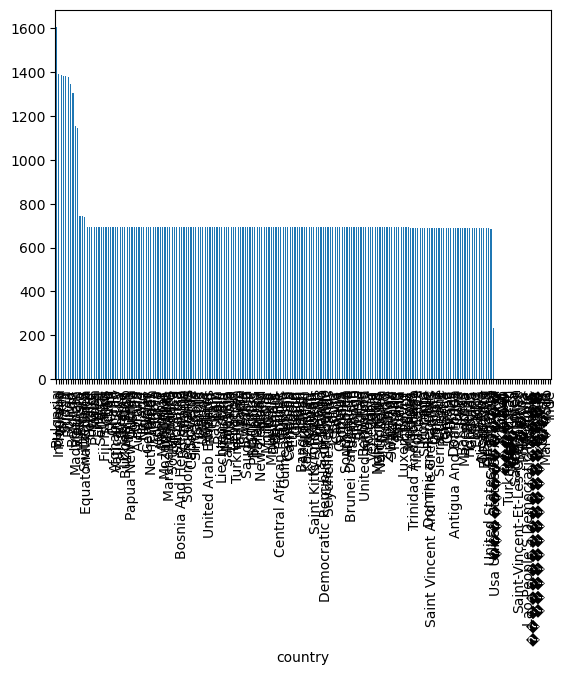

```python
freq = df["country"].value_counts()
freq.plot(kind = 'bar')
```

##### This bar chart shows the frequency of countries in the dataset. It helps compare how many records belong to each country.

### Timezone

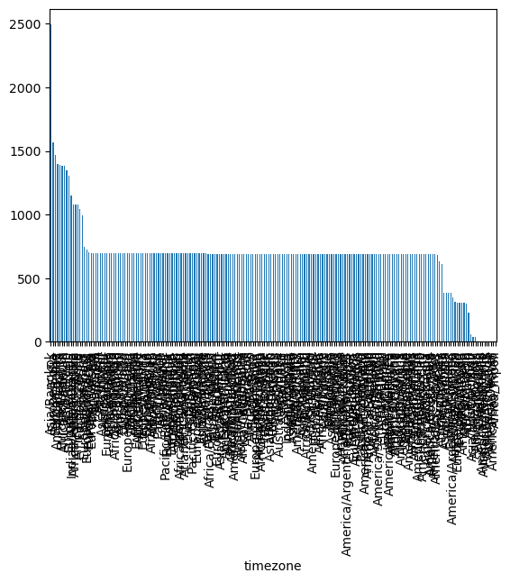

```python
freq = df["timezone"].value_counts()
freq.plot(kind = 'bar')
```

### Location Name

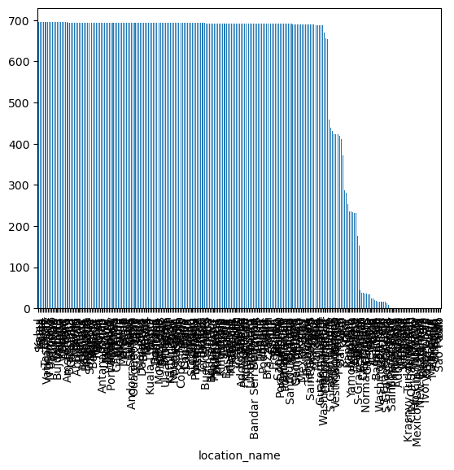

```python
freq = df["location_name"].value_counts()
freq.plot(kind = 'bar')
```

##### This bar chart shows the frequency of location names in the dataset. It helps compare how many records are available for each location.

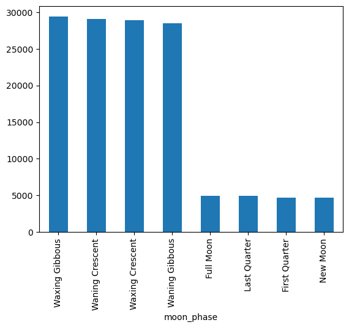

```python
freq = df["moon_phase"].value_counts()
freq.plot(kind = 'bar')
```

### Condition Text

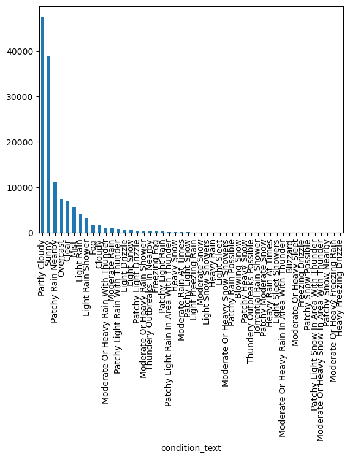

```python
freq = df["condition_text"].value_counts()
freq.plot(kind = 'bar')
```

##### This bar chart shows the frequency of weather conditions in the dataset. It helps compare how often each weather condition appears.

### City

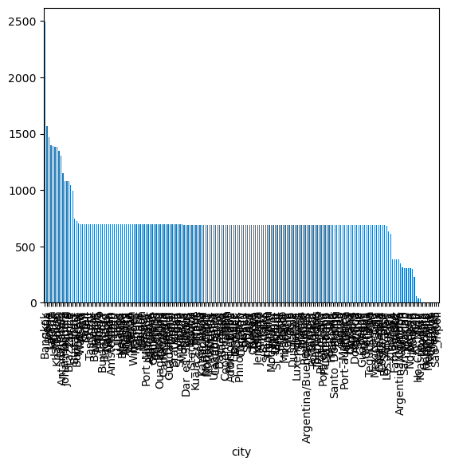

```python
freq = df["city"].value_counts()
freq.plot(kind = 'bar')
```

##### This bar chart shows the frequency of cities in the dataset. It helps compare how many records are available for each city.

### Continent

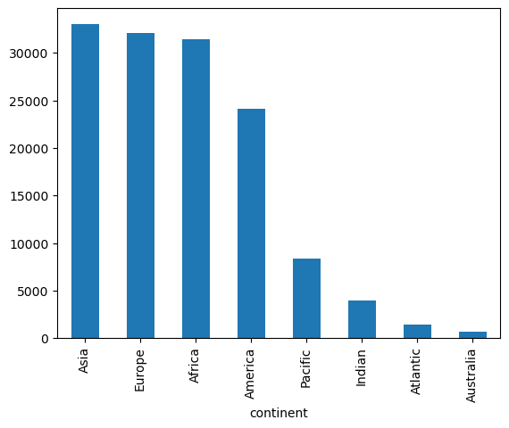

```python
freq = df["continent"].value_counts()
freq.plot(kind = 'bar')
```

##### This bar chart shows the frequency of continents in the dataset. It helps compare how many records belong to each continent.

### Country

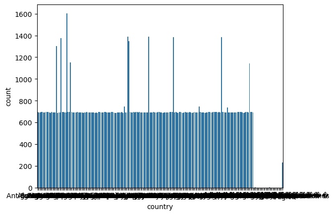

```python
import seaborn as sna
sns.countplot(x="country",data=df)
plt.show()
```

### Location Name

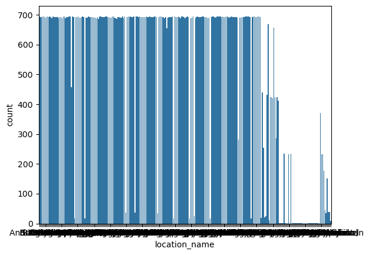

```python
import seaborn as sns
sns.countplot(x="location_name",data=df)
plt.show()
```

### Condition Text

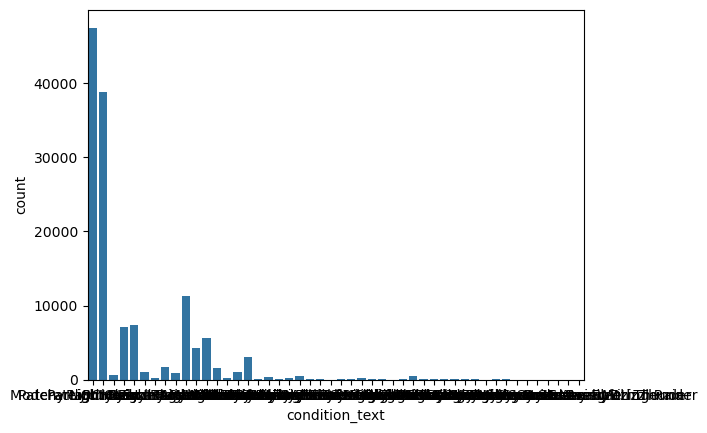

```python
import seaborn as sna
sns.countplot(x="condition_text",data=df)
plt.show()
```

##### This count plot shows the frequency of each weather condition in the dataset. It helps compare how often different weather conditions occur.

### Moon Phase

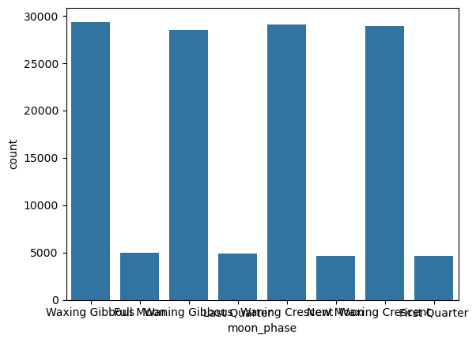

```python
import seaborn as sna
sns.countplot(x="moon_phase",data=df)
plt.show()
```

##### It shows the frequency of each moon phase in the dataset and helps compare how often each phase appears.

# Weather Conditions

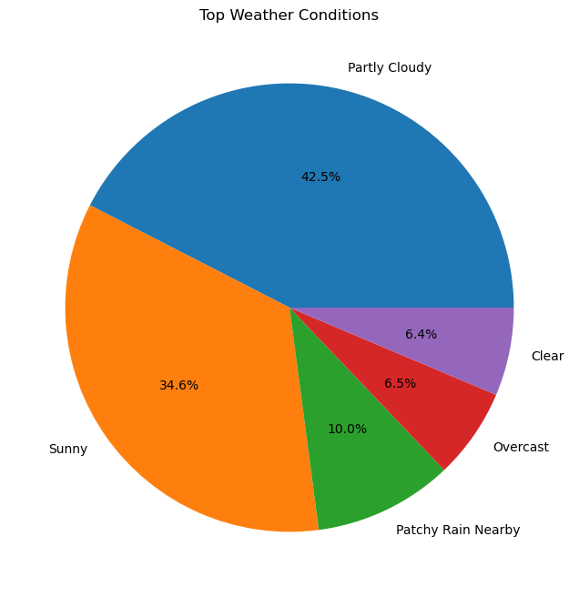

```python
condition_data = df['condition_text'].value_counts().head(5)

plt.figure(figsize=(8,8))
plt.pie(condition_data, labels=condition_data.index, autopct='%1.1f%%')
plt.title("Top Weather Conditions")
plt.show()
```

##### This pie chart shows the top 5 most common weather conditions. It helps compare the percentage share of each condition in the dataset.

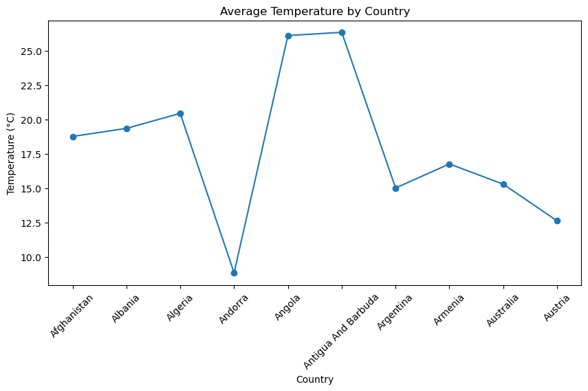

```python
temp_data = df.groupby('country')['temperature_celsius'].mean().head(10)

plt.figure(figsize=(10,5))
plt.plot(temp_data.index, temp_data.values, marker='o')
plt.title("Average Temperature by Country")
plt.xlabel("Country")
plt.ylabel("Temperature (°C)")
plt.xticks(rotation=45)
plt.show()
```

##### This line chart shows the average temperature of the first 10 countries. It helps compare temperature levels and identify variations between countries.

# 3. BAR CHART

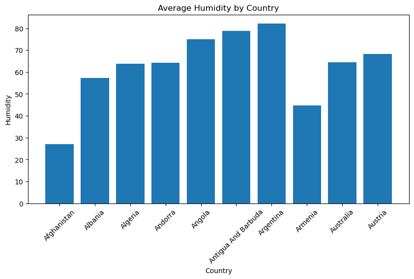

```python
humidity_data = df.groupby('country')['humidity'].mean().head(10)

plt.figure(figsize=(10,5))
plt.bar(humidity_data.index, humidity_data.values)
plt.title("Average Humidity by Country")
plt.xlabel("Country")
plt.ylabel("Humidity")
plt.xticks(rotation=45)
plt.show()
```

##### This bar chart shows the average humidity of the first 10 countries. It helps compare humidity levels between countries and identify higher or lower average values.

# 4. Histogram

#### Temperature Distribution

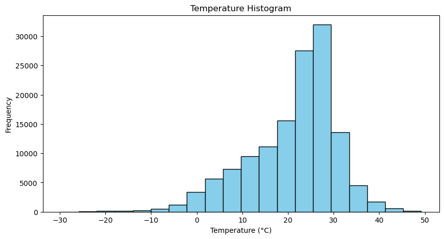

```python
import matplotlib.pyplot as plt

plt.figure(figsize=(10,5))

plt.hist(df['temperature_celsius'],
         bins=20,
         color='skyblue',
         edgecolor='black')

plt.title("Temperature Histogram")
plt.xlabel("Temperature (°C)")
plt.ylabel("Frequency")

plt.show()
```

##### This histogram shows the distribution of temperature values. It helps understand the frequency, range, and common temperature levels in the dataset.

# 5. Box Plot

#### Temperature

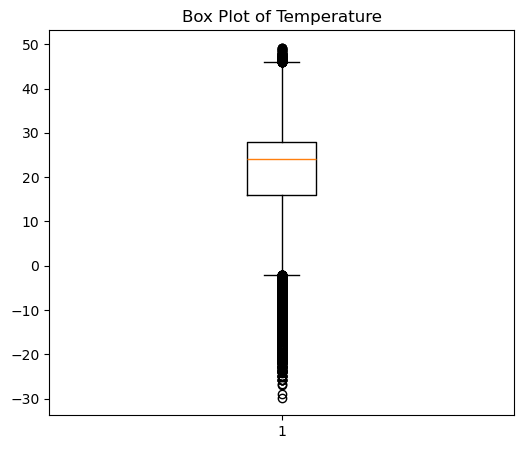

```python
plt.figure(figsize=(6,5))
plt.boxplot(df['temperature_celsius'])
plt.title("Box Plot of Temperature")
plt.show()
```

##### This box plot shows the distribution of temperature values. It helps identify the median, spread, and any outliers in the temperature data.

# Compare Two Columns

#### Temperature vs Humidity

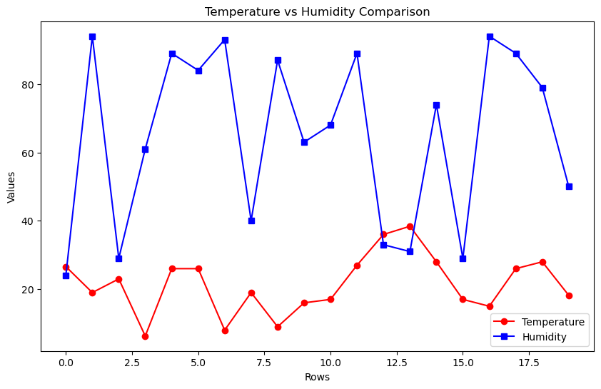

```python
plt.figure(figsize=(10,6))

plt.plot(df['temperature_celsius'].head(20),
         label='Temperature',
         color='red',
         marker='o')

plt.plot(df['humidity'].head(20),
         label='Humidity',
         color='blue',
         marker='s')

plt.title("Temperature vs Humidity Comparison")
plt.xlabel("Rows")
plt.ylabel("Values")
plt.legend()
```

##### This line chart compares temperature and humidity for the first 20 records. It helps identify variations, trends, and differences between temperature and humidity values across rows.

# Numerical Relationship

### Scatter Plot

```python
gf=df.loc[:10]
```

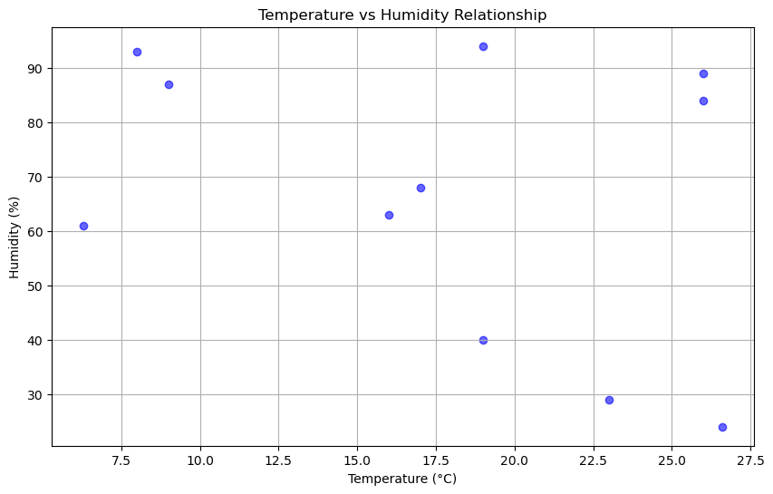

```python
plt.figure(figsize=(10,6))

plt.scatter(gf['temperature_celsius'],
            gf['humidity'],
            color='blue',
            alpha=0.6)

plt.title("Temperature vs Humidity Relationship")
plt.xlabel("Temperature (°C)")
plt.ylabel("Humidity (%)")
plt.grid(True)
plt.show()
```

##### The scatter plot shows the relationship between temperature and humidity. Each point represents a weather record. If points are scattered, the relationship is weak. If points slope downward, humidity decreases as temperature increases. It helps identify patterns and correlation.

### (Day 5)

# DATA VISUALISATION

### Global Temperature Distribution

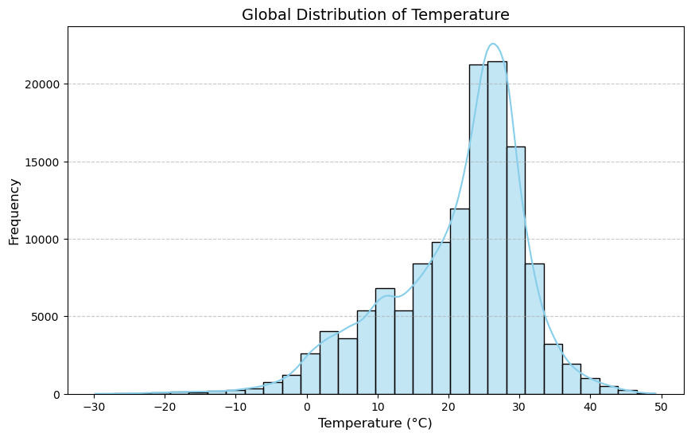

```python
plt.figure(figsize=(10,6))
sns.histplot(df["temperature_celsius"], bins=30, kde=True, color="skyblue")
plt.title("Global Distribution of Temperature", fontsize=14)
plt.xlabel("Temperature (°C)", fontsize=12)
plt.ylabel("Frequency", fontsize=12)
plt.grid(axis='y', linestyle='--', alpha=0.7)
plt.show()
```

##### The graph shows that most temperature values are between **15°C and 30°C**. Extreme low and high temperatures are less common globally.

### Most Common Weather Condition

```python
print("Most Common Weather Condition Worldwide:")
print(condition_counts.idxmax())
print("Count:", condition_counts.max())
plt.figure(figsize=(12,6))
sns.barplot(
    x=condition_counts.head(10).values,
    y=condition_counts.head(10).index,
    palette="viridis")
plt.title("Top 10 Most Common Weather Conditions Worldwide")
plt.xlabel("Frequency")
plt.ylabel("Weather Condition")
plt.show()
```

[output not shown]

```
Most Common Weather Condition Worldwide:
```

[output not shown]

### Average Global Level (PM 2.5,PM 10)

```
Global Average PM2.5: 24.21
Global Average PM10 : 48.43
```

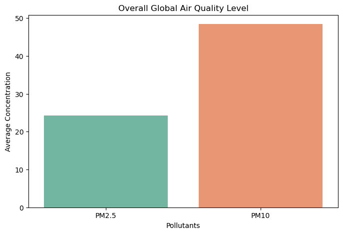

```python
avg_pm25 = df["air_quality_PM2.5"].mean()
avg_pm10 = df["air_quality_PM10"].mean()

print("Global Average PM2.5:", round(avg_pm25,2))
print("Global Average PM10 :", round(avg_pm10,2))
pollutants = ["PM2.5", "PM10"]
values = [avg_pm25, avg_pm10]
plt.figure(figsize=(8,5))
sns.barplot(x=pollutants, y=values, palette="Set2")
plt.title("Overall Global Air Quality Level")
plt.xlabel("Pollutants")
plt.ylabel("Average Concentration")
plt.show()
```